# KSU Data Science Programming Boot Camp 2019 - R

#### 3.3 Web API

```r
# install the package only if it is not installed
if (!require(twitteR)) {
  install.packages("twitteR")
}
```

```r
library(httr)
library(devtools)
library(twitteR)
```

```r
# replace all these credentials by your own
# to get credentials, follow the tutorial https://medium.com/@GalarnykMichael/accessing-data-from-twitter-api-using-r-part1-b387a1c7d3e
consumer_key <- "puxmqW5Fb9zV3wddFzwGYmcCj"
consumer_secret <- "rtP4AYjMxvaKIzIl2a9JNBP26cnBHYJQb7H35cpcHuQC0tEzVY"
access_token <- "2607567668-XhrG0Ywtzh13FgcSgzobhAIqz1KrG0w4xJNxRQ3"
access_secret <- "xOhkVZQrIwfJnxR865B51rgNq1tqLb7WDVRRGmoIiMFbp"
```

```r
# pass credentials to the function setup_twitter_oauth() to connect to twitter API
setup_twitter_oauth(consumer_key, consumer_secret, access_token, access_secret)
```

```
[1] "Using direct authentication"
```

```r
# specify query keyword, the number of tweets to query, tweet language, tweet within certain time period
tw = searchTwitter("data science", n=100, lang='en', since = "2019-08-04", until = "2019-08-05")
# get the description and usage of the function searchTwitter()
?searchTwitter
```

```r
# convert the retrieved tweets to a dataframe
d = twListToDF(tw)
# get the description and usage of the function twListToDF()
?twListToDF
```

```r
# check all columns
colnames(d)
```

```
 [1] "text"          "favorited"     "favoriteCount" "replyToSN"     "created"
 [6] "truncated"     "replyToSID"    "id"            "replyToUID"    "statusSource"
[11] "screenName"    "retweetCount"  "isRetweet"     "retweeted"     "longitude"
[16] "latitude"
```

```r
# display the first 5 rows
head(d,5)
```

|  | text | favorited | favoriteCount | replyToSN | created | truncated | replyToSID | id | replyToUID | statusSource | screenName | retweetCount | isRetweet | retweeted | longitude | latitude |
| --- | --- | --- | --- | --- | --- | --- | --- | --- | --- | --- | --- | --- | --- | --- | --- | --- |
| 1 | RT @Cernovich: The data is clear about not having children, grandchildren. Living your last years out alone is a choice people can make, no… | FALSE | 0 | NA | 2019-08-04 23:58:38 | FALSE | NA | 1158165377618198533 | NA | Twitter Web App | TrentTamra | 104 | TRUE | FALSE | NA | NA |
| 2 | RT @Cernovich: The data is clear about not having children, grandchildren. Living your last years out alone is a choice people can make, no… | FALSE | 0 | NA | 2019-08-04 23:58:17 | FALSE | NA | 1158165288094822400 | NA | Twitter Web App | BredlauMary | 104 | TRUE | FALSE | NA | NA |
| 3 | RT @Cernovich: The data is clear about not having children, grandchildren. Living your last years out alone is a choice people can make, no… | FALSE | 0 | NA | 2019-08-04 23:57:11 | FALSE | NA | 1158165013984698379 | NA | Twitter Web App | IamSeerious | 104 | TRUE | FALSE | NA | NA |
| 4 | RT @KirkDBorne: [Free 479-page eBook from Microsoft]\nThe #Mathematics and #Statistics Foundations of #DataScience: https://t.co/7lYeig5OhE… | FALSE | 0 | NA | 2019-08-04 23:57:07 | FALSE | NA | 1158164996125286400 | NA | Twitter Web App | datagz | 131 | TRUE | FALSE | NA | NA |
| 5 | @vandersee_grant @patstokes How much data analysis have you done on environmental science reports&amp;which sources? I… https://t.co/hUvm7NUYdO | FALSE | 1 | vandersee_grant | 2019-08-04 23:56:53 | TRUE | 1157622990508449793 | 1158164939510444032 | 731407442710384644 | Twitter for Android | _childofthesea_ | 0 | FALSE | FALSE | NA | NA |

```r
# save the queried tweets to a local file named tw.csv
write.csv(d, file = "tw.csv", row.names=FALSE)
```

# Part 4: Data Management

======================================

#### 4.1 Merge & Append

#### 4.2 Matrix Algebra

#### 4.3 Statistical Functions

======================================

##### Preparation

```r
# set the working directory
setwd("/Users/lilizhang/OneDrive - Kennesaw State University/BOOTCAMP/BootCamp_R_2019")
# load the datasets
clean1a <- read.csv("CLEAN1A.csv", header = TRUE)
clean1b <- read.csv("CLEAN1B.csv", header = TRUE)
notclean1a <- read.csv("NOTCLEAN1A.csv", header = TRUE)
notclean1b <- read.csv("NOTCLEAN1B.csv", header = TRUE)
```

#### 4.1 Merge/Append

##### Merge: to add variables/columns.

- At least one common variable is required when two datasets are merging.
- Function: merge()

reference: http://www.datasciencemadesimple.com/join-in-r-merge-in-r/

##### Merge clean1a and clean1b horizontally

```r
head(clean1a)
```

|  | MATCHKEY | RBAL | TRADES | AGE |
| --- | --- | --- | --- | --- |
| 1 | 16345246 | 1492 | 4 | 39 |
| 2 | 13728016 | 0 | 3 | 71 |
| 3 | 14716776 | 854 | 9 | 30 |
| 4 | 14568809 | 408 | 13 | 28 |
| 5 | 13513749 | 4965 | 41 | 51 |
| 6 | 4379593 | 1847 | 15 | 43 |

```r
head(clean1b)
```

|  | MATCHKEY | DELQID | CRELIM | goodbad |
| --- | --- | --- | --- | --- |
| 1 | 16345246 | 1 | 750 | 0 |
| 2 | 13728016 | 0 | 3250 | 0 |
| 3 | 14716776 | 4 | 500 | 1 |
| 4 | 14568809 | 1 | 3000 | 0 |
| 5 | 13513749 | 0 | 500 | 0 |
| 6 | 4379593 | 0 | 4750 | 0 |

```r
# Inner join
inner_merged <- merge(clean1a, clean1b, by="MATCHKEY")
head(inner_merged)
```

|  | MATCHKEY | RBAL | TRADES | AGE | DELQID | CRELIM | goodbad |
| --- | --- | --- | --- | --- | --- | --- | --- |
| 1 | 1338454 | 10446 | 21 | 46 | 1 | 6000 | 0 |
| 2 | 1343107 | 16600 | 8 | 29 | 1 | 3800 | 0 |
| 3 | 1374470 | 17418 | 18 | 29 | 0 | 6000 | 0 |
| 4 | 1427263 | 5976 | 15 | 53 | 7 | 4300 | 1 |
| 5 | 1431876 | 3809 | 23 | 56 | 0 | 5750 | 0 |
| 6 | 1438286 | 32699 | 13 | 34 | 0 | 2000 | 0 |

```r
?merge
```

```r
dim(inner_merged)
```

```
[1] 1000    7
```

```r
# Left join
left_merged <- merge(clean1a, clean1b, by="MATCHKEY", all.x = TRUE)
head(left_merged)
```

|  | MATCHKEY | RBAL | TRADES | AGE | DELQID | CRELIM | goodbad |
| --- | --- | --- | --- | --- | --- | --- | --- |
| 1 | 1338454 | 10446 | 21 | 46 | 1 | 6000 | 0 |
| 2 | 1343107 | 16600 | 8 | 29 | 1 | 3800 | 0 |
| 3 | 1374470 | 17418 | 18 | 29 | 0 | 6000 | 0 |
| 4 | 1427263 | 5976 | 15 | 53 | 7 | 4300 | 1 |
| 5 | 1431876 | 3809 | 23 | 56 | 0 | 5750 | 0 |
| 6 | 1438286 | 32699 | 13 | 34 | 0 | 2000 | 0 |

```r
# Right join --> all.y = TRUE
```

```r
dim(left_merged)
```

```
[1] 1000    7
```

```r
# right join
right_merged <- merge(clean1a, clean1b, by="MATCHKEY", all.y = TRUE)
head(right_merged)
```

|  | MATCHKEY | RBAL | TRADES | AGE | DELQID | CRELIM | goodbad |
| --- | --- | --- | --- | --- | --- | --- | --- |
| 1 | 1338454 | 10446 | 21 | 46 | 1 | 6000 | 0 |
| 2 | 1343107 | 16600 | 8 | 29 | 1 | 3800 | 0 |
| 3 | 1374470 | 17418 | 18 | 29 | 0 | 6000 | 0 |
| 4 | 1427263 | 5976 | 15 | 53 | 7 | 4300 | 1 |
| 5 | 1431876 | 3809 | 23 | 56 | 0 | 5750 | 0 |
| 6 | 1438286 | 32699 | 13 | 34 | 0 | 2000 | 0 |

```r
dim(right_merged)
```

```
[1] 1000    7
```

```r
# Outer join --> all=TRUE
outer_merged <- merge(clean1a, clean1b, by="MATCHKEY", all=TRUE)
head(outer_merged)
```

|  | MATCHKEY | RBAL | TRADES | AGE | DELQID | CRELIM | goodbad |
| --- | --- | --- | --- | --- | --- | --- | --- |
| 1 | 1338454 | 10446 | 21 | 46 | 1 | 6000 | 0 |
| 2 | 1343107 | 16600 | 8 | 29 | 1 | 3800 | 0 |
| 3 | 1374470 | 17418 | 18 | 29 | 0 | 6000 | 0 |
| 4 | 1427263 | 5976 | 15 | 53 | 7 | 4300 | 1 |
| 5 | 1431876 | 3809 | 23 | 56 | 0 | 5750 | 0 |
| 6 | 1438286 | 32699 | 13 | 34 | 0 | 2000 | 0 |

```r
dim(outer_merged)
```

```
[1] 1000    7
```

##### Append: to add observations/rows.

- Variables should have exactly the same name when two datasets are appending.
- Function: rbind()

##### Join clean1a and notclean1a vertically

```r
nrow(clean1a)
```

```
[1] 1000
```

```r
nrow(notclean1a)
```

```
[1] 1000
```

```r
combine <- rbind(clean1a, notclean1a)
nrow(combine)
```

```
[1] 2000
```

#### 4.2 Matrix Algebra

##### Inputting a matrix into R

- cbind(): to append columns together
- rbind(): to append rows together
- matrix(): to create a matrix from an input vector

##### Various Matrix Operations

- Transpose operator: t()
- Inverse: solve()
- Determinant of a matrix: det()
- diag(): to return the vector of diagonal elements if used on a matrix; to returns a matrix with 0’s off-diagonal and the input vector on the diagonal if used on a vector

##### Example

```r
A <- matrix(1:9, nrow = 3, byrow = TRUE)
A
```

```
     [,1] [,2] [,3]
[1,]    1    2    3
[2,]    4    5    6
[3,]    7    8    9
```

```r
print('diag of a matrix')
```

```
[1] "diag of a matrix"
```

```r
diag(A)
```

```
[1] 1 5 9
```

```r
print('diag of a vector')
```

```
[1] "diag of a vector"
```

```r
B <- diag(diag(A))
B
```

```
     [,1] [,2] [,3]
[1,]    1    0    0
[2,]    0    5    0
[3,]    0    0    9
```

```r
print('matrix addition: A + B')
```

```
[1] "matrix addition: A + B"
```

```r
A + B
```

```
     [,1] [,2] [,3]
[1,]    2    2    3
[2,]    4   10    6
[3,]    7    8   18
```

```r
print('matrix subtraction: A - B')
```

```
[1] "matrix subtraction: A - B"
```

```r
A - B
```

```
     [,1] [,2] [,3]
[1,]    0    2    3
[2,]    4    0    6
[3,]    7    8    0
```

```r
print('matrix multiplication: A %*% B')
```

```
[1] "matrix multiplication: A %*% B"
```

```r
A %*% B
```

```
     [,1] [,2] [,3]
[1,]    1   10   27
[2,]    4   25   54
[3,]    7   40   81
```

```r
print('elementwise multiplication: A * B')
```

```
[1] "elementwise multiplication: A * B"
```

```r
A * B
```

```
     [,1] [,2] [,3]
[1,]    1    0    0
[2,]    0   25    0
[3,]    0    0   81
```

```r
print('transpose of A')
```

```
[1] "transpose of A"
```

```r
t(A)
```

```
     [,1] [,2] [,3]
[1,]    1    4    7
[2,]    2    5    8
[3,]    3    6    9
```

```r
print('inverse of B')
```

```
[1] "inverse of B"
```

```r
solve(B)
```

```
     [,1] [,2]      [,3]
[1,]    1  0.0 0.0000000
[2,]    0  0.2 0.0000000
[3,]    0  0.0 0.1111111
```

```r
print('determinant of A')
```

```
[1] "determinant of A"
```

```r
det(A)
```

```
[1] 6.661338e-16
```

#### 4.3 Statistical Functions

- mean(), sd(), var(), median(), min(), max(), quantile()
- to generate random variables: rnorm(), rbinom(), etc.
- to calculate probabilities: dnorm(), dbinom(), etc.
- to calculate cumulative probabilities: pnorm(), pbinom(), etc.
- to determine quantiles/percentiles/critical values: qnorm(), etc.

```r
sd(clean1a$AGE)
```

```
[1] 15.55152
```

```r
var(clean1a$AGE)
```

```
[1] 241.8499
```

```r
# quantile function
quantile(clean1a$AGE)
```

```
   0%   25%   50%   75%  100%
19.00 35.75 47.00 59.00 92.00
```

```r
quantile(clean1a$AGE, c(0.025, 0.975))
```

```
  2.5%  97.5%
22.000 79.025
```

reference: http://seankross.com/notes/dpqr/

```r
# probablity distributions
rnorm(5, mean=0, sd=1)
```

```
[1]  0.8168998 -0.8863575 -0.3315776  1.1207127  0.2987237
```

```r
rnorm(5,mean=20, sd=4)
```

```
[1] 23.11849 25.82314 17.42269 13.78745 13.60916
```

```r
?rnorm
```

```r
# The function dnorm returns the value of the probability density function for the normal distribution given parameters
dnorm(0,  mean=0, sd=1)
```

```
[1] 0.3989423
```

```r
# What is the Z-score of the pth quantile of the normal distribution?
qnorm(0.95, mean=0, sd=1)
```

```
[1] 1.644854
```

```r
# The function pnorm returns the integral from −∞ to q of the pdf of the normal distribution where q is a Z-score.
pnorm(1, mean=0, sd=1)
```

```
[1] 0.8413447
```

```r
pnorm(1,mean=0, sd=1, lower=FALSE) # the lower=FALSE option to get the probability that X ≥ x
```

```
[1] 0.1586553
```

```r
?pnorm
```

# Part 5: Data Exploratory Analysis

======================================

#### 5.1 Univariate Analysis

#### 5.2 Bivariate Analysis

======================================

```r
head(inner_merged)
```

|  | MATCHKEY | RBAL | TRADES | AGE | DELQID | CRELIM | goodbad |
| --- | --- | --- | --- | --- | --- | --- | --- |
| 1 | 1338454 | 10446 | 21 | 46 | 1 | 6000 | 0 |
| 2 | 1343107 | 16600 | 8 | 29 | 1 | 3800 | 0 |
| 3 | 1374470 | 17418 | 18 | 29 | 0 | 6000 | 0 |
| 4 | 1427263 | 5976 | 15 | 53 | 7 | 4300 | 1 |
| 5 | 1431876 | 3809 | 23 | 56 | 0 | 5750 | 0 |
| 6 | 1438286 | 32699 | 13 | 34 | 0 | 2000 | 0 |

```r
str(inner_merged)
```

```
'data.frame':   1000 obs. of  7 variables:
 $ MATCHKEY: int  1338454 1343107 1374470 1427263 1431876 1438286 1447849 1503556 1525288 1538046 ...
 $ RBAL    : int  10446 16600 17418 5976 3809 32699 321 16568 9646 2750 ...
 $ TRADES  : int  21 8 18 15 23 13 22 41 13 17 ...
 $ AGE     : int  46 29 29 53 56 34 39 51 34 44 ...
 $ DELQID  : int  1 1 0 7 0 0 4 0 0 0 ...
 $ CRELIM  : num  6000 3800 6000 4300 5750 2000 1500 4000 2000 2400 ...
 $ goodbad : int  0 0 0 1 0 0 1 0 0 0 ...
```

#### 5.1 Univariate Analysis

##### continuous variable

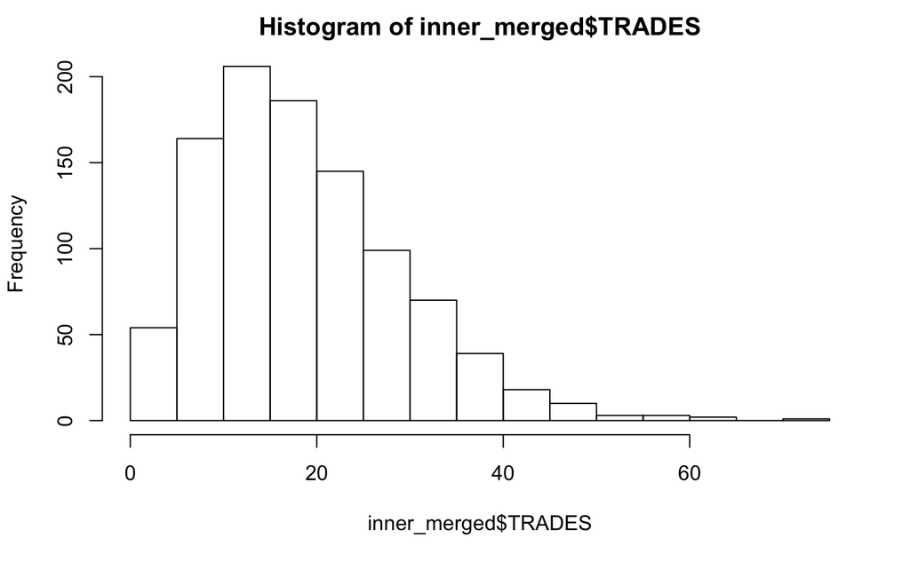

```r
hist(inner_merged$TRADES)
```

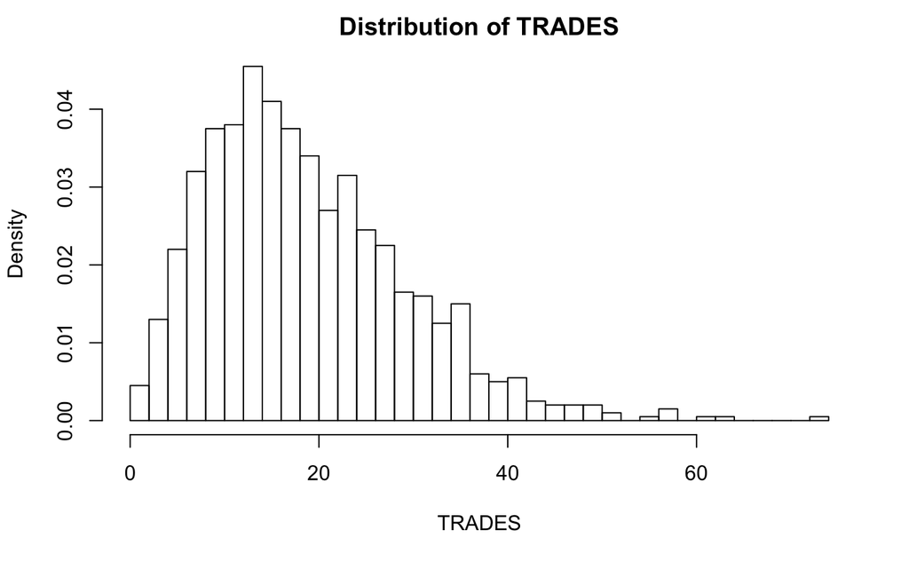

```r
hist(inner_merged$TRADES, breaks=50, xlab = "TRADES", freq = FALSE, main = "Distribution of TRADES")
```

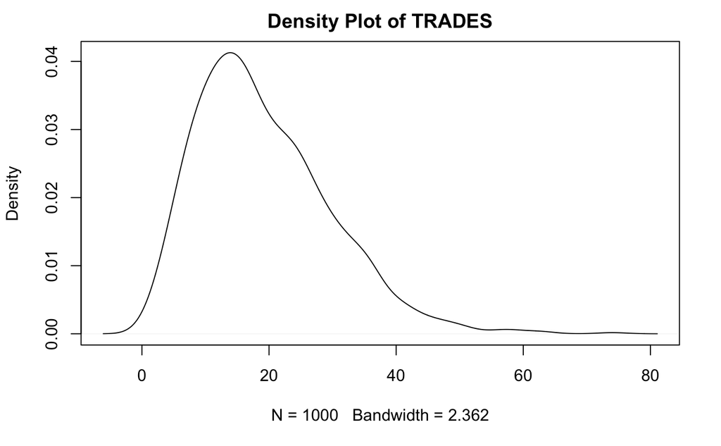

```r
plot(density(inner_merged$TRADES, na.rm = TRUE), main="Density Plot of TRADES")
```

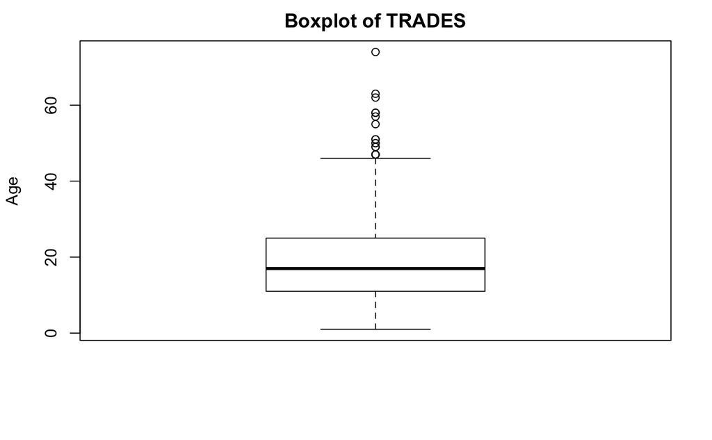

```r
boxplot(inner_merged$TRADES, ylab="Age", main="Boxplot of TRADES")
```

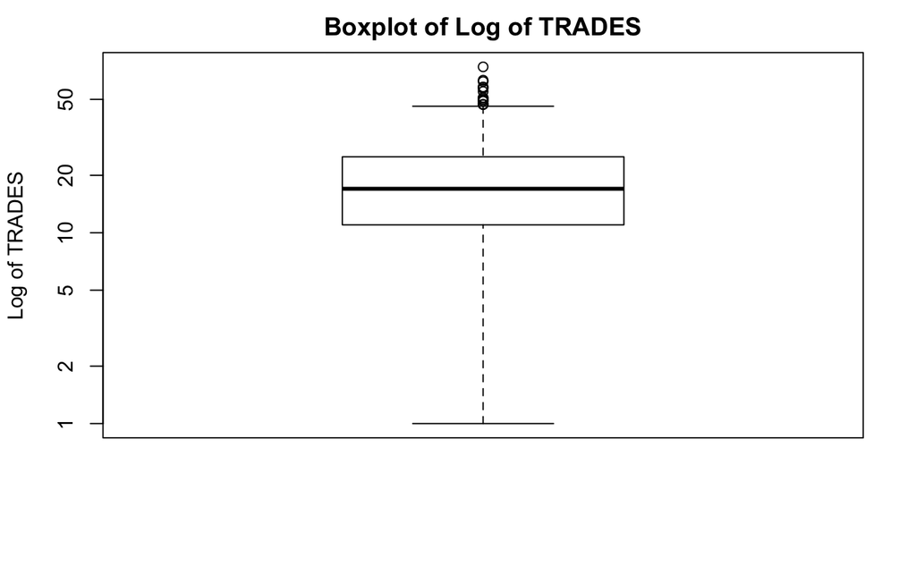

```r
boxplot(inner_merged$TRADES, log="y", ylab="Log of TRADES", main="Boxplot of Log of TRADES")
```

##### categorical variable

```r
table(inner_merged$goodbad)
```

```
  0   1
813 187
```

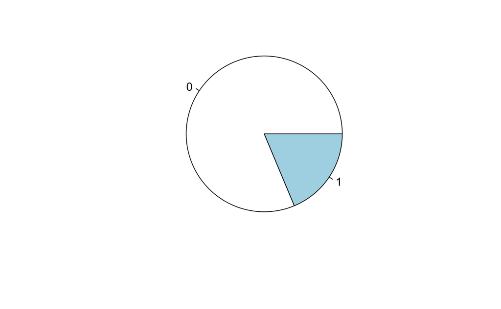

```r
pie(table(inner_merged$goodbad))
```

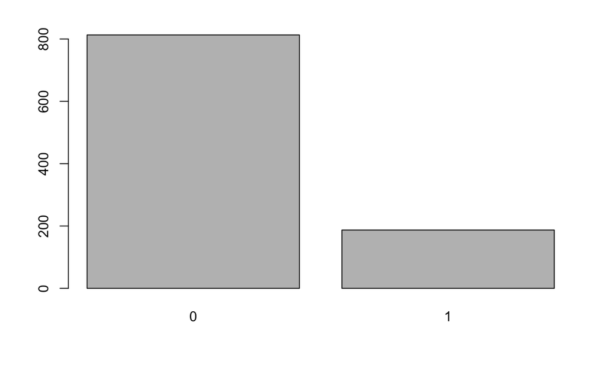

```r
barplot(table(inner_merged$goodbad))
```

#### 5.2 Bivariate Analysis

##### Two Categorical Variables

```r
table(inner_merged$goodbad,inner_merged$DELQID)
```

```
      0   1   2   3   4   5   6   7
  0 576 182  55   0   0   0   0   0
  1   0   0   0  22  23  26  12 104
```

```r
#reference: http://www.r-tutor.com/elementary-statistics/goodness-fit/chi-squared-test-independence
chisq.test(inner_merged$goodbad,inner_merged$DELQID)
```

```
Chi-squared approximation may be incorrect
```

```
    Pearson's Chi-squared test

data:  inner_merged$goodbad and inner_merged$DELQID
X-squared = 1000, df = 7, p-value < 2.2e-16
```

```r
?chisq.test
```

```r
tbl = table(inner_merged$goodbad,inner_merged$DELQID)
```

```r
tbl = table(inner_merged$goodbad,inner_merged$DELQID)
ctbl = cbind(tbl[,"0"], tbl[,"1"], tbl[,"2"], tbl[,"3"] + tbl[,"4"]++ tbl[,"5"]++ tbl[,"6"], tbl[,"7"])
```

```r
chisq.test(ctbl)
```

```
    Pearson's Chi-squared test

data:  ctbl
X-squared = 1000, df = 4, p-value < 2.2e-16
```

##### Two Continuous Variables

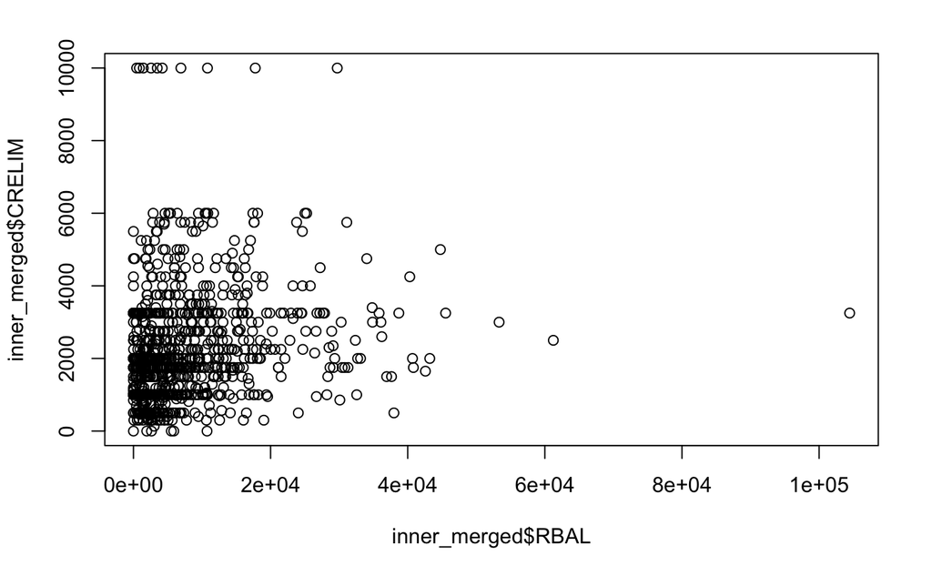

```r
plot(inner_merged$RBAL, inner_merged$CRELIM)
```

```r
cor(inner_merged$RBAL, inner_merged$CRELIM)
```

```
[1] 0.1901208
```

```r
cor(inner_merged)
```

```
            MATCHKEY        RBAL      TRADES         AGE      DELQID       CRELIM     goodbad
MATCHKEY  1.00000000 -0.09619852 0.018088073  0.01272677  0.05835793 -0.194309467  0.03970616
RBAL     -0.09619852  1.00000000 0.437462744  0.18878113  0.02729679  0.190120798  0.04229645
TRADES    0.01808807  0.43746274 1.000000000  0.19866815  0.01152578  0.005028388  0.02433745
AGE       0.01272677  0.18878113 0.198668149  1.00000000 -0.07645892  0.065571106 -0.06345124
DELQID    0.05835793  0.02729679 0.011525782 -0.07645892  1.00000000 -0.173251539  0.92971253
CRELIM   -0.19430947  0.19012080 0.005028388  0.06557111 -0.17325154  1.000000000 -0.15076965
goodbad   0.03970616  0.04229645 0.024337447 -0.06345124  0.92971253 -0.150769649  1.00000000
```

##### One Continuous Variable and One Categorical Variable

```r
boxplot(CRELIM~goodbad, data=inner_merged)
legend(0.6,34,"0=good") # to add the legend
```

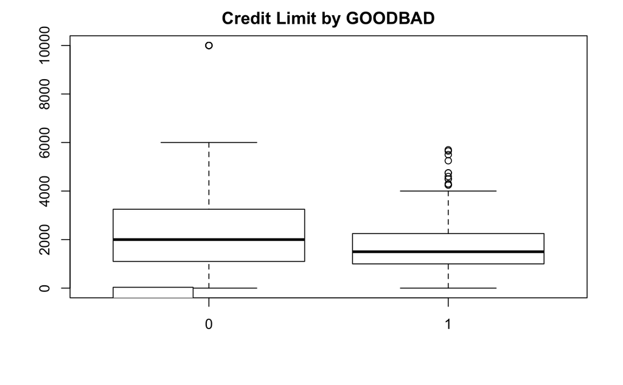

```r
title("Credit Limit by GOODBAD") # to add chart title
```

```r
t.test(CRELIM~goodbad, data=inner_merged)
```

```
CRELIM ~ goodbad

    Welch Two Sample t-test

data:  CRELIM by goodbad
t = 5.6913, df = 349.26, p-value = 2.673e-08
alternative hypothesis: true difference in means is not equal to 0
95 percent confidence interval:
 387.5523 796.8581
sample estimates:
mean in group 0 mean in group 1
       2326.392        1734.187
```

# Part 6: Modeling

======================================

#### 6.1 Variable Selection

#### 6.2 Train Test Split

#### 6.3 Logistic Regression

#### 6.4 Linear Regression

======================================

#### 6.1 Variable Selection

```r
inner_merged_copy <- subset(inner_merged, select=-c(DELQID, MATCHKEY))
```

```r
head(inner_merged_copy)
```

|  | RBAL | TRADES | AGE | CRELIM | goodbad |
| --- | --- | --- | --- | --- | --- |
| 1 | 10446 | 21 | 46 | 6000 | 0 |
| 2 | 16600 | 8 | 29 | 3800 | 0 |
| 3 | 17418 | 18 | 29 | 6000 | 0 |
| 4 | 5976 | 15 | 53 | 4300 | 1 |
| 5 | 3809 | 23 | 56 | 5750 | 0 |
| 6 | 32699 | 13 | 34 | 2000 | 0 |

#### 6.2 Train Test Split

```r
# install the package only if it is not installed
if (!require(caTools)) {
  install.packages("caTools")
}
```

```r
library(caTools)
```

```r
set.seed(100)
split <- sample.split(inner_merged_copy$goodbad, SplitRatio = 0.7)
```

```r
#get training and test data
trainingData <- subset(inner_merged_copy, split == TRUE)
testData <- subset(inner_merged_copy, split == FALSE)
trainingData$goodbad <- as.factor(trainingData$goodbad)
testData$goodbad <- as.factor(testData$goodbad)
```

```r
head(trainingData)
```

|  | RBAL | TRADES | AGE | CRELIM | goodbad |
| --- | --- | --- | --- | --- | --- |
| 1 | 10446 | 21 | 46 | 6000 | 0 |
| 2 | 16600 | 8 | 29 | 3800 | 0 |
| 3 | 17418 | 18 | 29 | 6000 | 0 |
| 5 | 3809 | 23 | 56 | 5750 | 0 |
| 6 | 32699 | 13 | 34 | 2000 | 0 |
| 7 | 321 | 22 | 39 | 1500 | 1 |

```r
dim(trainingData)
```

```
[1] 700   5
```

```r
head(testData)
```

|  | RBAL | TRADES | AGE | CRELIM | goodbad |
| --- | --- | --- | --- | --- | --- |
| 4 | 5976 | 15 | 53 | 4300 | 1 |
| 9 | 9646 | 13 | 34 | 2000 | 0 |
| 15 | 15144 | 42 | 70 | 2200 | 0 |
| 18 | 4593 | 16 | 30 | 6000 | 0 |
| 24 | 23272 | 28 | 47 | 3100 | 1 |
| 28 | 11304 | 19 | 32 | 3000 | 0 |

```r
dim(testData)
```

```
[1] 300   5
```

#### 6.3 Logistic Regression Model

##### the dependent variable is categorical/binary

```r
# train model
logistic_model <- glm(goodbad ~ RBAL + TRADES
 + AGE + CRELIM , data=trainingData, family=binomial(link="logit"))
```

```r
summary(logistic_model)
```

```
Call:
glm(formula = goodbad ~ RBAL + TRADES + AGE + CRELIM, family = binomial(link = "logit"),
    data = trainingData)

Deviance Residuals:
    Min       1Q   Median       3Q      Max
-1.3027  -0.6900  -0.5860  -0.4358   2.3342

Coefficients:
              Estimate Std. Error z value Pr(>|z|)
(Intercept) -6.470e-01  3.692e-01  -1.752 0.079715 .
RBAL         2.215e-05  1.150e-05   1.926 0.054058 .
TRADES       1.157e-02  1.018e-02   1.136 0.255992
AGE         -1.344e-02  6.780e-03  -1.982 0.047527 *
CRELIM      -2.928e-04  8.386e-05  -3.492 0.000479 ***
---
Signif. codes:  0 ‘***’ 0.001 ‘**’ 0.01 ‘*’ 0.05 ‘.’ 0.1 ‘ ’ 1

(Dispersion parameter for binomial family taken to be 1)

    Null deviance: 674.87  on 699  degrees of freedom
Residual deviance: 651.50  on 695  degrees of freedom
AIC: 661.5

Number of Fisher Scoring iterations: 5
```

```r
# predicted probability on the test data
testData$logisticProba <- predict(logistic_model, testData, type="response")
# testData$logisticProba <- plogis(predict(logistic_model, testData))
```

```r
head(testData)
```

|  | RBAL | TRADES | AGE | CRELIM | goodbad | logisticProba |
| --- | --- | --- | --- | --- | --- | --- |
| 4 | 5976 | 15 | 53 | 4300 | 1 | 0.09009919 |
| 9 | 9646 | 13 | 34 | 2000 | 0 | 0.20991022 |
| 15 | 15144 | 42 | 70 | 2200 | 0 | 0.19615598 |
| 18 | 4593 | 16 | 30 | 6000 | 0 | 0.07444661 |
| 24 | 23272 | 28 | 47 | 3100 | 1 | 0.20636333 |
| 28 | 11304 | 19 | 32 | 3000 | 0 | 0.18462526 |

```r
describe(testData$goodbad)
```

```
testData$goodbad
       n  missing distinct
     300        0        2

Value          0     1
Frequency    244    56
Proportion 0.813 0.187
```

```r
testData$logisticPrediction <- cut(testData$logisticProba, breaks=c(0, 0.187, 1), labels=c(0,1))
```

```r
head(testData)
```

|  | RBAL | TRADES | AGE | CRELIM | goodbad | logisticProba | logisticPrediction |
| --- | --- | --- | --- | --- | --- | --- | --- |
| 4 | 5976 | 15 | 53 | 4300 | 1 | 0.09009919 | 0 |
| 9 | 9646 | 13 | 34 | 2000 | 0 | 0.20991022 | 1 |
| 15 | 15144 | 42 | 70 | 2200 | 0 | 0.19615598 | 1 |
| 18 | 4593 | 16 | 30 | 6000 | 0 | 0.07444661 | 0 |
| 24 | 23272 | 28 | 47 | 3100 | 1 | 0.20636333 | 1 |
| 28 | 11304 | 19 | 32 | 3000 | 0 | 0.18462526 | 0 |

```r
# install the package only if it is not installed
if (!require(InformationValue)) {
  install.packages("InformationValue")
}
```

```r
library(InformationValue)
```

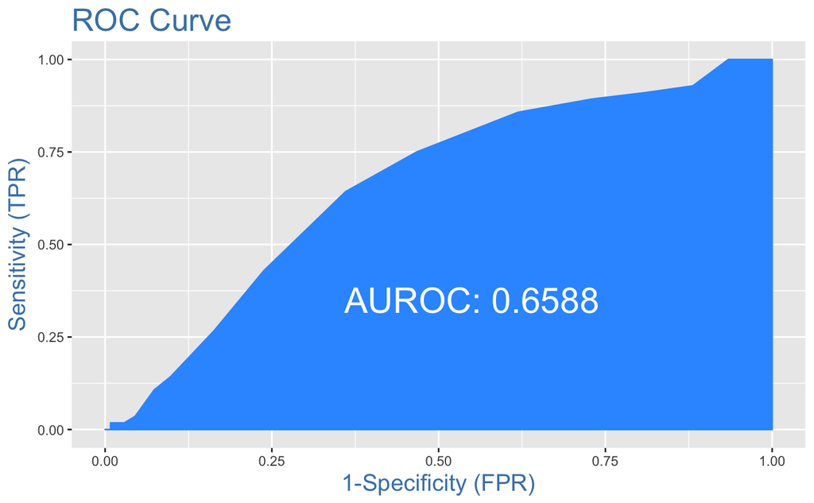

```r
plotROC(testData$goodbad, testData$logisticProba)
```

```r
# install the package only if it is not installed
if (!require(caret)) {
  install.packages("caret")
}
```

```r
library(caret)
```

```r
cm <- confusionMatrix(testData$logisticPrediction, testData$goodbad, positive="1")
cm
```

```
Confusion Matrix and Statistics

          Reference
Prediction   0   1
         0 140  17
         1 104  39

               Accuracy : 0.5967
                 95% CI : (0.5388, 0.6526)
    No Information Rate : 0.8133
    P-Value [Acc > NIR] : 1

                  Kappa : 0.169

 Mcnemar's Test P-Value : 5.359e-15

            Sensitivity : 0.6964
            Specificity : 0.5738
         Pos Pred Value : 0.2727
         Neg Pred Value : 0.8917
             Prevalence : 0.1867
         Detection Rate : 0.1300
   Detection Prevalence : 0.4767
      Balanced Accuracy : 0.6351

       'Positive' Class : 1
```

```r
?confusionMatrix
```

```r
str(cm)
```

```
List of 6
 $ positive: chr "1"
 $ table   : 'table' int [1:2, 1:2] 140 104 17 39
  ..- attr(*, "dimnames")=List of 2
  .. ..$ Prediction: chr [1:2] "0" "1"
  .. ..$ Reference : chr [1:2] "0" "1"
 $ overall : Named num [1:7] 0.597 0.169 0.539 0.653 0.813 ...
  ..- attr(*, "names")= chr [1:7] "Accuracy" "Kappa" "AccuracyLower" "AccuracyUpper" ...
 $ byClass : Named num [1:11] 0.696 0.574 0.273 0.892 0.273 ...
  ..- attr(*, "names")= chr [1:11] "Sensitivity" "Specificity" "Pos Pred Value" "Neg Pred Value" ...
 $ mode    : chr "sens_spec"
 $ dots    : list()
 - attr(*, "class")= chr "confusionMatrix"
```

```r
accuracy <- cm$overall[["Accuracy"]]
print(paste0("Accuracy: ", accuracy * 100, "%"))
```

```
[1] "Accuracy: 59.6666666666667%"
```

```r
type_I_error <- 1- cm$byClass[["Specificity"]]
print(paste0("Type I Error: ", type_I_error*100, "%"))
```

```
[1] "Type I Error: 42.6229508196721%"
```

```r
type_II_error <- 1 - cm$byClass[["Sensitivity"]]
print(paste0("Type II Error: ", type_II_error*100, "%"))
```

```
[1] "Type II Error: 30.3571428571429%"
```

```r
?paste0
```

```r
for (cutoff in seq(0.000001, 0.999999, 0.1)){
  print(paste0("cutoff: ", cutoff))
  testData$logisticPrediction <- cut(testData$logisticProba, breaks=c(0, cutoff, 1), labels=c(0,1))
  cm <- confusionMatrix(testData$logisticPrediction, testData$goodbad, positive="1")
  accuracy <- cm$overall[["Accuracy"]]
  print(paste0("Accuracy: ", accuracy * 100, "%"))
  # type I error = false positive rate; specificity = true negative rate
  type_I_error <- 1- cm$byClass[["Specificity"]]
  print(paste0("Type I Error: ", type_I_error*100, "%"))
  # type II error = false negative rate; sensitivity = true positive rate
  type_II_error <- 1 - cm$byClass[["Sensitivity"]]
  print(paste0("Type II Error: ", type_II_error*100, "%" ))
  cat("\n")
}
```

```
[1] "cutoff: 1e-06"
[1] "Accuracy: 18.6666666666667%"
[1] "Type I Error: 100%"
[1] "Type II Error: 0%"

[1] "cutoff: 0.100001"
[1] "Accuracy: 27%"
[1] "Type I Error: 88.1147540983607%"
[1] "Type II Error: 7.14285714285714%"

[1] "cutoff: 0.200001"
[1] "Accuracy: 64%"
[1] "Type I Error: 36.0655737704918%"
[1] "Type II Error: 35.7142857142857%"

```

[output cut: 34 more lines]

for more information on confusion matrix, refer to https://www.dataschool.io/simple-guide-to-confusion-matrix-terminology/ https://en.wikipedia.org/wiki/Confusion_matrix

for more tutorials on handling class imbalance problem, refer to https://www.r-bloggers.com/handling-class-imbalance-with-r-and-caret-caveats-when-using-the-auc/ https://www.analyticsvidhya.com/blog/2016/03/practical-guide-deal-imbalanced-classification-problems/

#### 6.4 Linear Regression Model

##### the dependent variable is continuous

```r
data(mtcars)
?mtcars
```

```r
head(mtcars)
```

|  | mpg | cyl | disp | hp | drat | wt | qsec | vs | am | gear | carb |
| --- | --- | --- | --- | --- | --- | --- | --- | --- | --- | --- | --- |
| Mazda RX4 | 21.0 | 6 | 160 | 110 | 3.90 | 2.620 | 16.46 | 0 | 1 | 4 | 4 |
| Mazda RX4 Wag | 21.0 | 6 | 160 | 110 | 3.90 | 2.875 | 17.02 | 0 | 1 | 4 | 4 |
| Datsun 710 | 22.8 | 4 | 108 | 93 | 3.85 | 2.320 | 18.61 | 1 | 1 | 4 | 1 |
| Hornet 4 Drive | 21.4 | 6 | 258 | 110 | 3.08 | 3.215 | 19.44 | 1 | 0 | 3 | 1 |
| Hornet Sportabout | 18.7 | 8 | 360 | 175 | 3.15 | 3.440 | 17.02 | 0 | 0 | 3 | 2 |
| Valiant | 18.1 | 6 | 225 | 105 | 2.76 | 3.460 | 20.22 | 1 | 0 | 3 | 1 |

```r
str(mtcars)
```

```
'data.frame':   32 obs. of  11 variables:
 $ mpg : num  21 21 22.8 21.4 18.7 18.1 14.3 24.4 22.8 19.2 ...
 $ cyl : num  6 6 4 6 8 6 8 4 4 6 ...
 $ disp: num  160 160 108 258 360 ...
 $ hp  : num  110 110 93 110 175 105 245 62 95 123 ...
 $ drat: num  3.9 3.9 3.85 3.08 3.15 2.76 3.21 3.69 3.92 3.92 ...
 $ wt  : num  2.62 2.88 2.32 3.21 3.44 ...
 $ qsec: num  16.5 17 18.6 19.4 17 ...
 $ vs  : num  0 0 1 1 0 1 0 1 1 1 ...
 $ am  : num  1 1 1 0 0 0 0 0 0 0 ...
 $ gear: num  4 4 4 3 3 3 3 4 4 4 ...
 $ carb: num  4 4 1 1 2 1 4 2 2 4 ...
```

```r
summary(mtcars)
```

```
      mpg             cyl             disp             hp             drat             wt
 Min.   :10.40   Min.   :4.000   Min.   : 71.1   Min.   : 52.0   Min.   :2.760   Min.   :1.513
 1st Qu.:15.43   1st Qu.:4.000   1st Qu.:120.8   1st Qu.: 96.5   1st Qu.:3.080   1st Qu.:2.581
 Median :19.20   Median :6.000   Median :196.3   Median :123.0   Median :3.695   Median :3.325
 Mean   :20.09   Mean   :6.188   Mean   :230.7   Mean   :146.7   Mean   :3.597   Mean   :3.217
 3rd Qu.:22.80   3rd Qu.:8.000   3rd Qu.:326.0   3rd Qu.:180.0   3rd Qu.:3.920   3rd Qu.:3.610
 Max.   :33.90   Max.   :8.000   Max.   :472.0   Max.   :335.0   Max.   :4.930   Max.   :5.424
      qsec             vs               am              gear            carb
 Min.   :14.50   Min.   :0.0000   Min.   :0.0000   Min.   :3.000   Min.   :1.000
 1st Qu.:16.89   1st Qu.:0.0000   1st Qu.:0.0000   1st Qu.:3.000   1st Qu.:2.000
 Median :17.71   Median :0.0000   Median :0.0000   Median :4.000   Median :2.000
 Mean   :17.85   Mean   :0.4375   Mean   :0.4062   Mean   :3.688   Mean   :2.812
 3rd Qu.:18.90   3rd Qu.:1.0000   3rd Qu.:1.0000   3rd Qu.:4.000   3rd Qu.:4.000
 Max.   :22.90   Max.   :1.0000   Max.   :1.0000   Max.   :5.000   Max.   :8.000
```

##### Check scatter plot matrix

```r
png(file="plot_matrix.png",width=2000, height=1700)
plot(mtcars)
```

##### Specify and estimate the model

```r
lm(mpg ~ wt + drat, data=mtcars)
```

```
Call:
lm(formula = mpg ~ wt + drat, data = mtcars)

Coefficients:
(Intercept)           wt         drat
     30.290       -4.783        1.442
```

```r
mtfit <- lm(mpg~wt + drat,data=mtcars)
```

##### Inference on the model parameters

```r
summary(mtfit)
```

```
Call:
lm(formula = mpg ~ wt + drat, data = mtcars)

Residuals:
    Min      1Q  Median      3Q     Max
-5.4159 -2.0452  0.0136  1.7704  6.7466

Coefficients:
            Estimate Std. Error t value Pr(>|t|)
(Intercept)   30.290      7.318   4.139 0.000274 ***
wt            -4.783      0.797  -6.001 1.59e-06 ***
drat           1.442      1.459   0.989 0.330854
---
Signif. codes:  0 ‘***’ 0.001 ‘**’ 0.01 ‘*’ 0.05 ‘.’ 0.1 ‘ ’ 1

Residual standard error: 3.047 on 29 degrees of freedom
Multiple R-squared:  0.7609,    Adjusted R-squared:  0.7444
F-statistic: 46.14 on 2 and 29 DF,  p-value: 9.761e-10
```

```r
summary.mtfit <- summary(mtfit)
```

```r
names(mtfit)
```

```
 [1] "coefficients"  "residuals"     "effects"       "rank"          "fitted.values"
 [6] "assign"        "qr"            "df.residual"   "xlevels"       "call"
[11] "terms"         "model"
```

```r
names(summary.mtfit)
```

```
 [1] "call"          "terms"         "residuals"     "coefficients"  "aliased"
 [6] "sigma"         "df"            "r.squared"     "adj.r.squared" "fstatistic"
[11] "cov.unscaled"
```

```r
mtfit$coefficients
```

```
(Intercept)          wt        drat
  30.290370   -4.782890    1.442491
```

```r
mtfit$coef
```

```
(Intercept)          wt        drat
  30.290370   -4.782890    1.442491
```

```r
summary.mtfit$coefficients
```

```
             Estimate Std. Error    t value     Pr(>|t|)
(Intercept) 30.290370  7.3178783  4.1392285 2.737824e-04
wt          -4.782890  0.7970353 -6.0008515 1.589075e-06
drat         1.442491  1.4585676  0.9889776 3.308544e-01
```

```r
summary.mtfit$coef
```

```
             Estimate Std. Error    t value     Pr(>|t|)
(Intercept) 30.290370  7.3178783  4.1392285 2.737824e-04
wt          -4.782890  0.7970353 -6.0008515 1.589075e-06
drat         1.442491  1.4585676  0.9889776 3.308544e-01
```

##### Check the design matrix

```r
model.matrix(mtfit)
```

```
                    (Intercept)    wt drat
Mazda RX4                     1 2.620 3.90
Mazda RX4 Wag                 1 2.875 3.90
Datsun 710                    1 2.320 3.85
Hornet 4 Drive                1 3.215 3.08
Hornet Sportabout             1 3.440 3.15
Valiant                       1 3.460 2.76
Duster 360                    1 3.570 3.21
Merc 240D                     1 3.190 3.69
Merc 230                      1 3.150 3.92
Merc 280                      1 3.440 3.92
Merc 280C                     1 3.440 3.92
Merc 450SE                    1 4.070 3.07
Merc 450SL                    1 3.730 3.07
Merc 450SLC                   1 3.780 3.07
Cadillac Fleetwood            1 5.250 2.93
Lincoln Continental           1 5.424 3.00
Chrysler Imperial             1 5.345 3.23
Fiat 128                      1 2.200 4.08
Honda Civic                   1 1.615 4.93
Toyota Corolla                1 1.835 4.22
Toyota Corona                 1 2.465 3.70
Dodge Challenger              1 3.520 2.76
AMC Javelin                   1 3.435 3.15
Camaro Z28                    1 3.840 3.73
Pontiac Firebird              1 3.845 3.08
Fiat X1-9                     1 1.935 4.08
Porsche 914-2                 1 2.140 4.43
Lotus Europa                  1 1.513 3.77
Ford Pantera L                1 3.170 4.22
Ferrari Dino                  1 2.770 3.62
Maserati Bora                 1 3.570 3.54
Volvo 142E                    1 2.780 4.11
attr(,"assign")
[1] 0 1 2
```

##### with/without the intercept

```r
lm(mpg ~ 1+wt+drat, data=mtcars)
```

```
Call:
lm(formula = mpg ~ 1 + wt + drat, data = mtcars)

Coefficients:
(Intercept)           wt         drat
     30.290       -4.783        1.442
```

```r
lm(mpg ~ -1 +wt+drat,data=mtcars)
```

```
Call:
lm(formula = mpg ~ -1 + wt + drat, data = mtcars)

Coefficients:
    wt    drat
-1.942   7.278
```

##### Add the quadratic term

```r
lm(mpg ~ wt+ I(wt^2), data=mtcars)
```

```
Call:
lm(formula = mpg ~ wt + I(wt^2), data = mtcars)

Coefficients:
(Intercept)           wt      I(wt^2)
     49.931      -13.380        1.171
```

##### Update the model

```r
mtfit2 <- update(mtfit, .~. -wt)
```

```r
mtfit2
```

```
Call:
lm(formula = mpg ~ drat, data = mtcars)

Coefficients:
(Intercept)         drat
     -7.525        7.678
```

```r
mtfit3 <- update(mtfit2, .~. + hp)
```

```r
mtfit3
```

```
Call:
lm(formula = mpg ~ drat + hp, data = mtcars)

Coefficients:
(Intercept)         drat           hp
   10.78986      4.69816     -0.05179
```

##### Compare different models based information criteria

```r
# the lower, the better
AIC(mtfit)
```

```
[1] 166.968
```

```r
AIC(mtfit2)
```

```
[1] 190.7999
```

```r
AIC(mtfit3)
```

```
[1] 169.5046
```

```r
# the lower, the better
BIC(mtfit)
```

```
[1] 172.8309
```

```r
BIC(mtfit2)
```

```
[1] 195.1971
```

```r
BIC(mtfit3)
```

```
[1] 175.3676
```

##### Compare simple and complex models based on ANOVA

```r
complexfit <- lm(mpg~wt+drat+hp+qsec+cyl, data=mtcars)
simplefit <- lm(mpg~wt+drat,data=mtcars)
```

```r
anova(simplefit,complexfit)
```

```
Analysis of Variance Table

Model 1: mpg ~ wt + drat
Model 2: mpg ~ wt + drat + hp + qsec + cyl
  Res.Df    RSS Df Sum of Sq      F   Pr(>F)
1     29 269.24
2     26 171.35  3    97.895 4.9515 0.007508 **
---
Signif. codes:  0 ‘***’ 0.001 ‘**’ 0.01 ‘*’ 0.05 ‘.’ 0.1 ‘ ’ 1
```

##### Check multicolinearity

```r
fit1 <- lm(mpg~drat+qsec+wt,data=mtcars)
```

```r
# install the package only if it is not installed
if (!require(regclass)) {
  install.packages("regclass")
}
```

```r
library(regclass)
```

```r
VIF(fit1)
```

```
    drat     qsec       wt
2.035472 1.033884 2.082097
```

##### Diagnoise the model

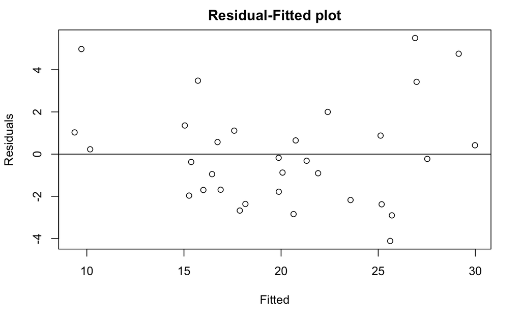

```r
plot(fit1$fit,fit1$res,xlab="Fitted",ylab="Residuals", main="Residual-Fitted plot")
abline(h=0)
```

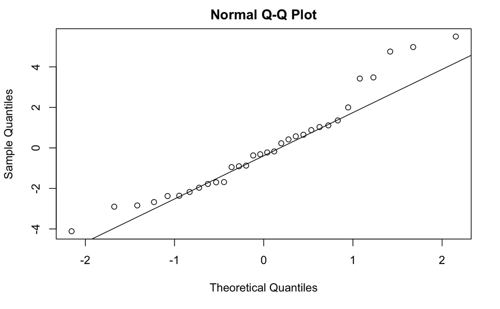

```r
qqnorm(resid(fit1))
qqline(resid(fit1))
```

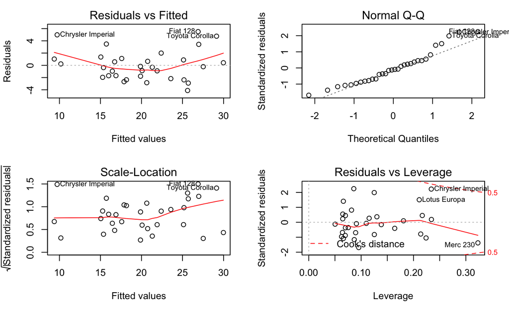

```r
par(mfrow=c(2,2))
plot(fit1)
```